# Exploring the Relationship Between Unemployment and Crime Rates in Chicago: A 2022 Analysis

2024-04-17

# Group Member:

- Anurag
- Yutai
- Bobby
- Adlin

# Introduction

Crime is a pervasive issue that affects communities across the United States, and understanding the factors that contribute to crime rates is crucial for developing effective strategies to reduce crime and improve public safety. This report aims to explore the relationship between crime rates and socioeconomic factors, specifically focusing on the unemployment rate, in community areas of Chicago. By analyzing crime data and demographic data from 2022, we seek to determine if there is a significant correlation between the unemployment rate and the crime rate, with a particular emphasis on violent crime. The motivation behind this analysis is to provide insights that can inform policy decisions and resource allocation aimed at reducing crime and promoting safer communities. The thesis statement of this report is as follows: Based on the analysis of crime and demographic data from Chicago in 2022, there is a significant positive correlation between the unemployment rate and the crime rate, particularly violent crime, in community areas of the city.

The primary question of interest in this analysis is: Is there a significant correlation between the unemployment rate and the crime rate, particularly violent crime, in Chicago community areas?

Based on the analysis of crime and demographic data from Chicago in 2022, we want to show that there is a significant positive correlation between the unemployment rate and the crime rate, particularly violent crime, in community areas of the city.

# Background

The analysis in this report utilizes two main datasets: crime data and demographic data for Chicago in 2022. The crime data is obtained from the “Crimes - 2001 to Present” dataset, which is publicly available on the Chicago Data Portal [(https://catalog.data.gov/dataset/crimes-2001-to-present)](https://catalog.data.gov/dataset/crimes-2001-to-present)[^1]. This dataset contains information about reported crimes in Chicago, including the date, primary type of crime, and the community area where the crime occurred. The data is collected and maintained by the Chicago Police Department.

The demographic data is sourced from the [“Community Data Snapshots Raw Data 2014-2022” dataset <sup>[^2]</sup>](https://datahub.cmap.illinois.gov/datasets/CMAPGIS::community-data-snapshots-raw-data-2014-2022/explore?layer=21), specifically the “CCA_2022” layer, which is available on the Chicago Metropolitan Agency for Planning (CMAP) Data Hub. This dataset provides information about the population, unemployment rate, and other socioeconomic indicators for each community area in Chicago.

The key variables used in the analysis are:

- Crime_Percent: The percentage of crimes in each community area relative to the total population.
- Unemployment_rate: The unemployment rate in each community area, calculated as the number of unemployed individuals divided by the total population.

To prepare the data for analysis, the crime data is filtered to include only records from 2022, and the relevant variables (date, primary type of crime, and community area) are selected. The demographic data is also filtered to include the relevant variables (community area, total population, and unemployment rate) for 2022. The two datasets are then merged based on the community area, allowing for the calculation of the crime percentage and unemployment rate for each area.

It is important to note that the crime data relies on reported crimes and may not capture all criminal activities in the city. Additionally, the analysis focuses on the relationship between the unemployment rate and crime rate at the community area level and does not consider other potential confounding factors that may influence crime rates, such as education levels, income inequality, or access to social services.

The report is structured in three parts. The first part focuses on a hypothesis test to determine if there is a significant correlation between the general crime rate and the unemployment rate. The second part explores the relationship between violent crime specifically and the unemployment rate. The third part provides visualizations of the data on geo maps to offer a spatial perspective on the distribution of crime and unemployment across the city.

Chicago Metropolitan Agency for Planning, N. (2023, June 21). Community Data Snapshots Raw Data (2014 - 2022). https://datahub.cmap.illinois.gov/datasets/CMAPGIS::community-data-snapshots-raw-data-2014-2022/about?layer=21

City of Chicago, (2010, November 10). Crimes - 2001 to Present. https://catalog.data.gov/dataset/crimes-2001-to-present

City of Chicago, (2024). Boundaries - Community Areas (current). https://data.cityofchicago.org/Facilities-Geographic-Boundaries/Boundaries-Community-Areas-current-/cauq-8yn6

# Analysis

## Data Preview

Before diving into the analysis, let’s take a quick look at the data.

### Crime Data 2022 (First 5 rows)

```
## # A tibble: 5 × 3
##   Date                   `Primary Type`             `Community Area`
##   <chr>                  <chr>                                 <dbl>
## 1 01/11/2022 03:00:00 PM SEX OFFENSE                              46
## 2 01/14/2022 03:55:00 PM OTHER OFFENSE                            68
## 3 01/13/2022 04:00:00 PM OFFENSE INVOLVING CHILDREN               23
## 4 08/05/2022 09:00:00 PM SEX OFFENSE                              69
## 5 08/14/2022 02:00:00 PM SEX OFFENSE                              11
```

```
## # A tibble: 5 × 259
##   OBJECTID GEOID GEOG  `2000_POP` `2010_POP` `2020_POP` `2020_HH` `2020_HH_SIZE`
##      <dbl> <dbl> <chr>      <dbl>      <dbl>      <dbl>     <dbl>          <dbl>
## 1        1    14 Alba…      57655      51542      48396     17161           2.74
## 2        2    57 Arch…      12644      13393      14196      4163           3.40
## 3        3    34 Armo…      12032      13391      13890      5648           2.45
## 4        4    70 Ashb…      39584      41081      41098     12909           3.14
## 5        5    71 Aubu…      55928      48743      44878     18071           2.48
## # ℹ 251 more variables: TOT_POP <dbl>, UND5 <dbl>, A5_19 <dbl>, A20_34 <dbl>,
## #   A35_49 <dbl>, A50_64 <dbl>, A65_74 <dbl>, A75_84 <dbl>, OV85 <dbl>,
## #   MED_AGE <dbl>, WHITE <dbl>, HISP <dbl>, BLACK <dbl>, ASIAN <dbl>,
## #   OTHER <dbl>, POP_HH <dbl>, POP_16OV <dbl>, IN_LBFRC <dbl>, EMP <dbl>,
## #   UNEMP <dbl>, NOT_IN_LBFRC <dbl>, TOT_WRKR16OV <dbl>, WORK_AT_HOME <dbl>,
## #   TOT_COMM <dbl>, DROVE_AL <dbl>, CARPOOL <dbl>, TRANSIT <dbl>,
## #   WALK_BIKE <dbl>, COMM_OTHER <dbl>, AGG_TT <dbl>, NO_VEH <dbl>, …
```

## Summary Statistics

### Crime Count by Community Area

```
##    Min. 1st Qu.  Median    Mean 3rd Qu.    Max.
##     303    1271    2194    3107    4050   12261
```

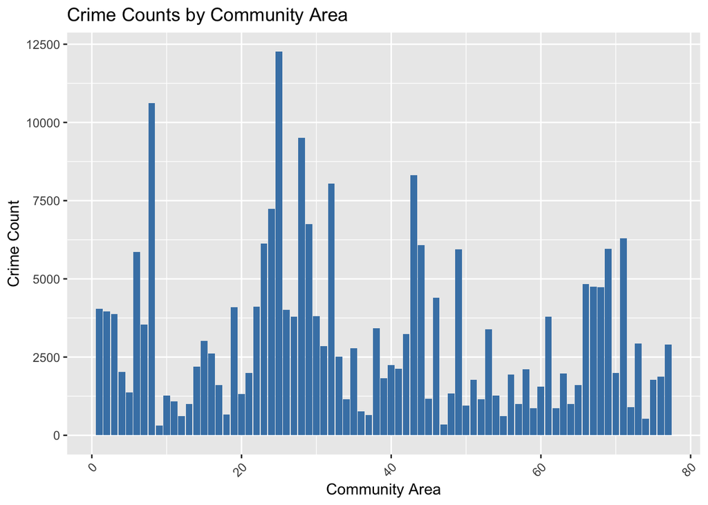

### Total Population by Community Area

```
##    Min. 1st Qu.  Median    Mean 3rd Qu.    Max.
##    2180   18523   29429   35050   46698  101428
```

```
##    Min. 1st Qu.  Median    Mean 3rd Qu.    Max.
##   116.0   733.9  1431.0  1559.3  2143.0  5786.0
```

```
##   Community Area total_population     UNEMP Year TOT_ACRES Crime_Count
## 1              1         49280.00 1869.0000 2022 1229.1605        4050
## 2              2         13533.00  551.0000 2022 1283.8041        3962
## 3              3         13438.84  444.6748 2022  637.4241        3872
## 4              4         42902.00 2244.0000 2022 3109.7414        2018
## 5              5         46698.00 3322.0000 2022 2411.9686        1375
##   Crime_Percent Unemployment_rate
## 1      8.218344          3.792614
## 2     29.276583          4.071529
## 3     28.812001          3.308877
## 4      4.703743          5.230525
## 5      2.944452          7.113795
```

```
##     Min.  1st Qu.   Median     Mean  3rd Qu.     Max.
##   0.3637   3.3768   8.2183  15.9962  17.9996 179.7687
```

```
##    Min. 1st Qu.  Median    Mean 3rd Qu.    Max.
##  0.4625  3.0862  3.9769  5.0763  7.5725 12.1931
```

## Statistical Tests

We are using correlation between two variables whether these variables are related to each other or not. The correlation coefficient r is a measure of the strength of a linear relationship between two quantitative variables x and y which are crime rate and unemployment rate.

$$r = \mathsf{Corr}(x,y)$$

We will also be calculating the 95% confidence interval and p-value in determining the strength correlation between these two variables

```
##
##  Pearson's product-moment correlation
##
## data:  vio_filtered$Unemployment_rate and vio_filtered$crime_percent
## t = 10.781, df = 75, p-value < 2.2e-16
## alternative hypothesis: true correlation is not equal to 0
## 95 percent confidence interval:
##  0.6731885 0.8544019
## sample estimates:
##       cor
## 0.7796168
```

## Visualizations

### Crime Counts by Community Area

This bar plot shows the total crime count for each community area in Chicago. It provides an overview of which areas have the highest and lowest crime counts.

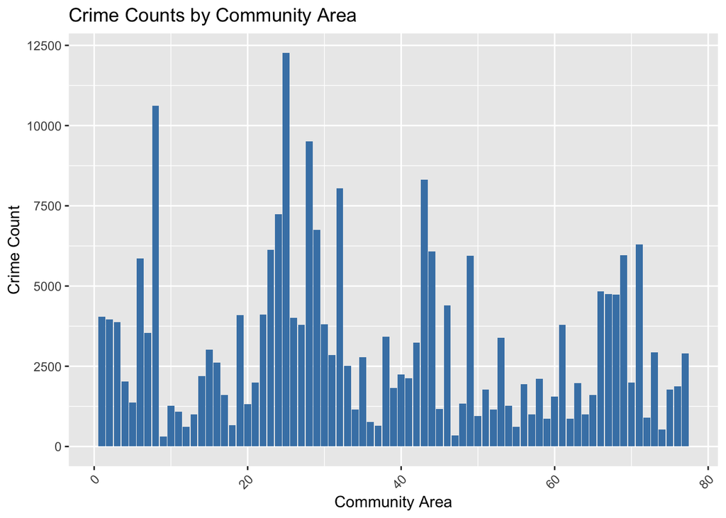

### Total Population by Community Area

This bar plot displays the total population for each community area in Chicago. It helps to understand the population distribution across different areas.

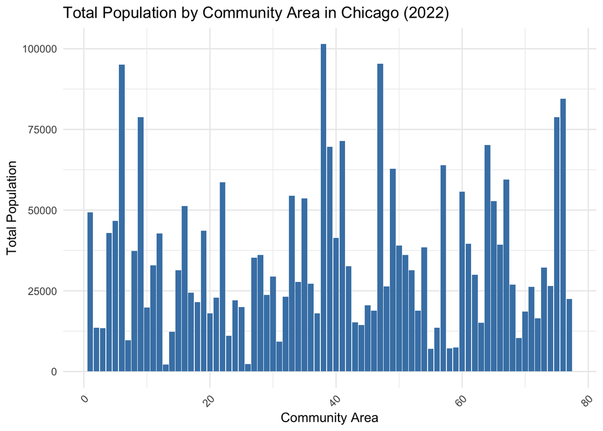

### Distribution of Crime

This density plot illustrates the distribution of total crime counts across community areas. It shows the shape of the distribution and identifies any potential outliers or unusual patterns.

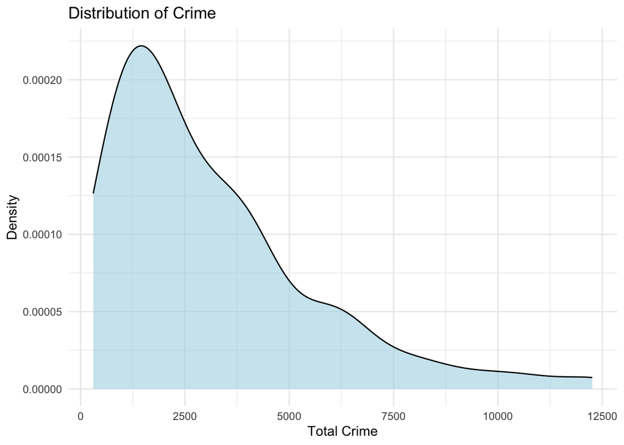

### Distribution of Population

This density plot represents the distribution of population across community areas. It provides insights into the population density and identifies areas with high or low population concentrations.

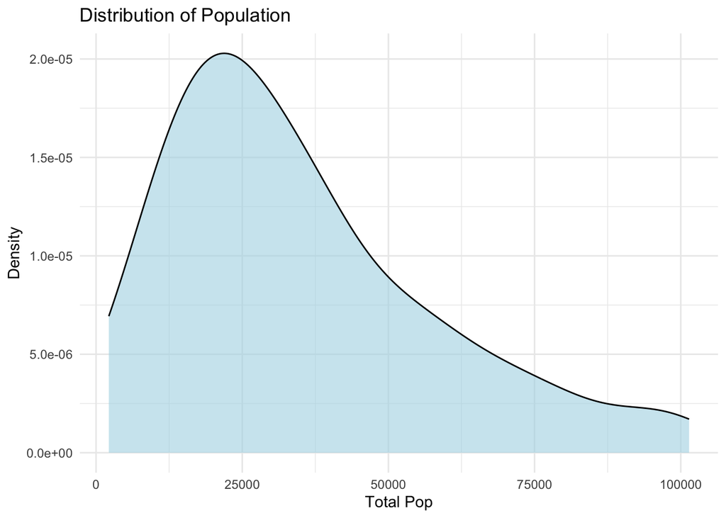

### Distribution of Unemployment Rate

This density plot displays the distribution of unemployment rates across community areas. It provides an overview of the unemployment situation in different parts of Chicago.

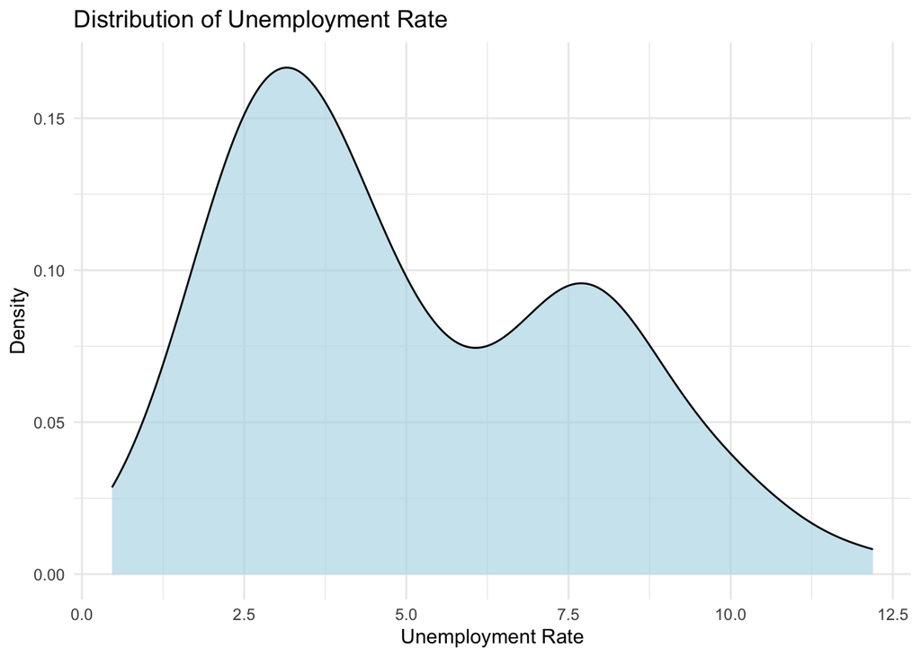

## Part 3: Visualization - Geo Maps

To visualize the spatial distribution of crime and unemployment across Chicago, we create geo maps using the crime and demographic data. The shapefile used for the community area boundaries is obtained from the City of Chicago’s Data Portal: [Boundaries - Community Areas (current)](https://data.cityofchicago.org/Facilities-Geographic-Boundaries/Boundaries-Community-Areas-current-/cauq-8yn6).

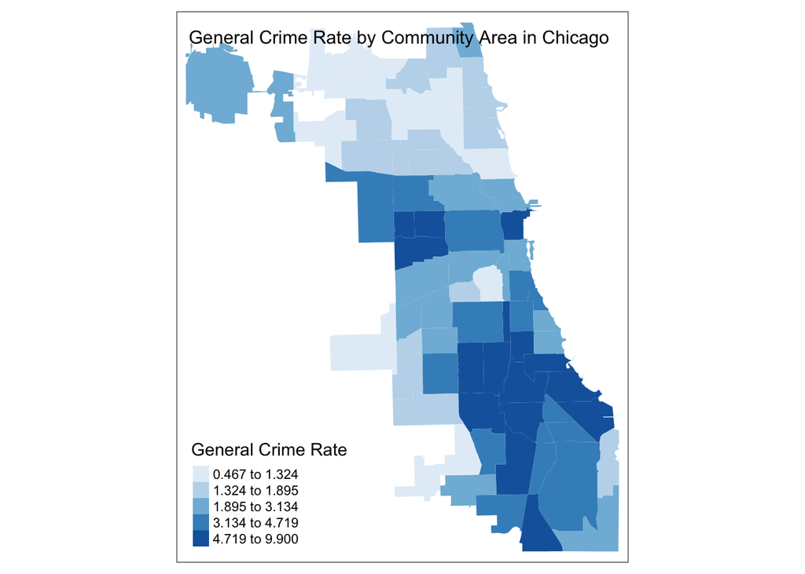

### Map 1: General Crime Rate

- Description: This map shows the distribution of the general crime rate across community areas in Chicago.

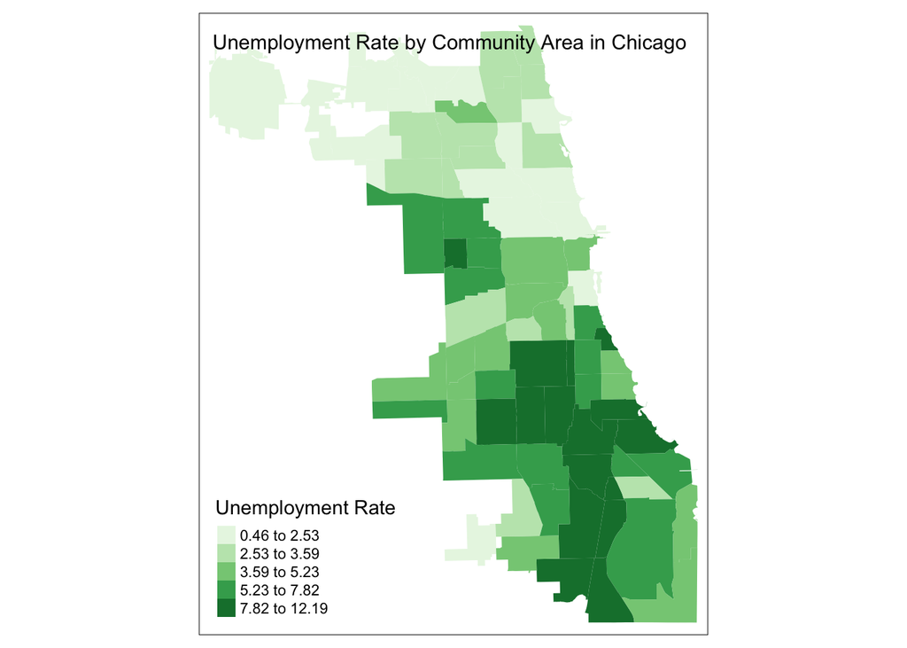

### Map 2: Unemployment Rate

- Description: This map shows the distribution of the unemployment rate across community areas in Chicago.
- Interpretation: The map highlights the spatial variability in unemployment rates, with certain community areas experiencing higher levels of unemployment compared to others.

[figure not shown]

### Map 3: Violent Crime Rate

- Description: This map shows the distribution of the violent crime rate across community areas in Chicago.
- Interpretation: The map identifies hotspots of violent crime, indicating the community areas that are disproportionately affected by violent offenses.

# Discussion:

Part1 Results:

Conducting Pearson’s product-moment correlation test between the unemployment rate and the violent crime rate yields the following results:

- Correlation coefficient: 0.780
- p-value: < 2.2e-16
- 95% confidence interval: (0.673, 0.854)

The correlation coefficient of 0.780 indicates a strong positive linear relationship between the unemployment rate and the violent crime rate. The p-value is extremely small (< 2.2e-16), providing strong evidence to reject the null hypothesis of no correlation. The 95% confidence interval does not include zero, further supporting the presence of a significant positive correlation.

These findings have important implications for policymakers and law enforcement agencies. They suggest that addressing unemployment and economic disparities in communities may have a positive impact on reducing violent crime. Targeted interventions and programs aimed at improving employment opportunities and providing support to individuals in high-unemployment areas could be effective strategies for promoting public safety.

However, it is crucial to acknowledge the limitations of this analysis. The study relies on reported crimes, which may not capture the full extent of criminal activity. Additionally, the analysis focuses on a single year of data and does not consider other socioeconomic factors that may influence crime rates.

Future research could expand on this work by incorporating additional variables, such as education levels, income inequality, and access to social services. Conducting a longitudinal analysis over multiple years could provide insights into the temporal dynamics of the relationship between unemployment and crime. Furthermore, qualitative studies involving community stakeholders and law enforcement personnel could offer valuable context and inform policy recommendations.

# Conclusion:

### Geo Maps Interpretation

#### Map 1: General Crime Rate

Description: This map displays the spatial distribution of the general crime rate across different community areas in Chicago. The darker shades of blue represent higher crime rates, while lighter shades indicate lower crime rates.

#### Map 2: Unemployment Rate

Description: This map visualizes the spatial variability in unemployment rates across community areas in Chicago. The darker shades of green represent higher levels of unemployment, while lighter shades indicate lower unemployment rates.

#### Map 3: Violent Crime Rate

Description: This map illustrates the distribution of the violent crime rate across different community areas in Chicago. The darker shades of red signify higher rates of violent crime, while lighter shades represent lower rates.

Correlation with the topic: This map is especially relevant to the analysis, as it directly visualizes the spatial patterns of violent crime rates, which were found to have a strong positive correlation with unemployment rates. By comparing this map with the unemployment rate map, it is possible to identify potential hotspots or clusters where high levels of violent crime coincide with areas of elevated unemployment. This visual representation supports the key finding that unemployment and violent crime are significantly correlated in Chicago community areas.

The findings emphasize the importance of addressing unemployment and economic disparities as part of a comprehensive approach to crime prevention and public safety. Policymakers and law enforcement agencies should consider targeted interventions and programs to improve employment opportunities and support individuals in high-unemployment areas.

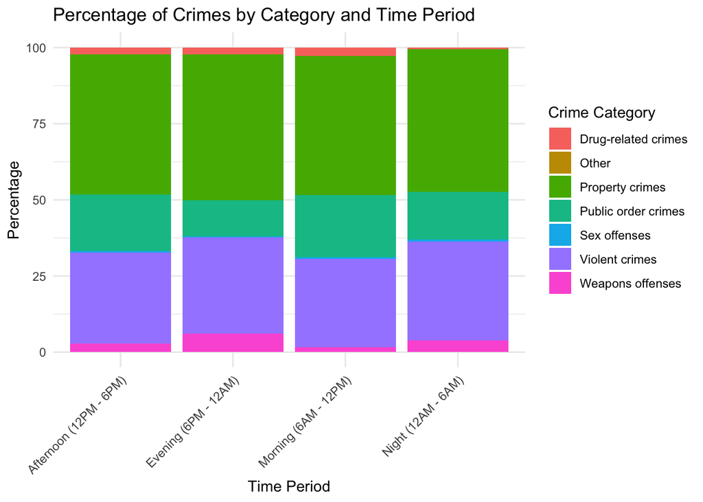

```
##
##  Pearson's Chi-squared test
##
## data:  contingency_table
## X-squared = 4216.4, df = 18, p-value < 2.2e-16
```

Other than that, there is also a correlation between races and crimes

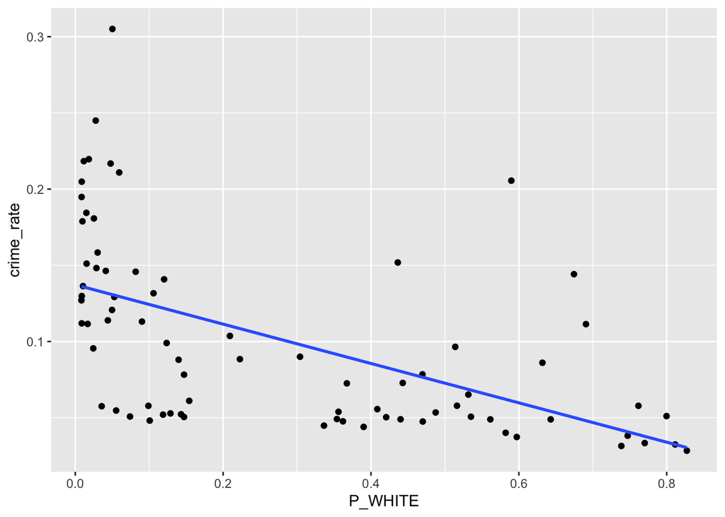

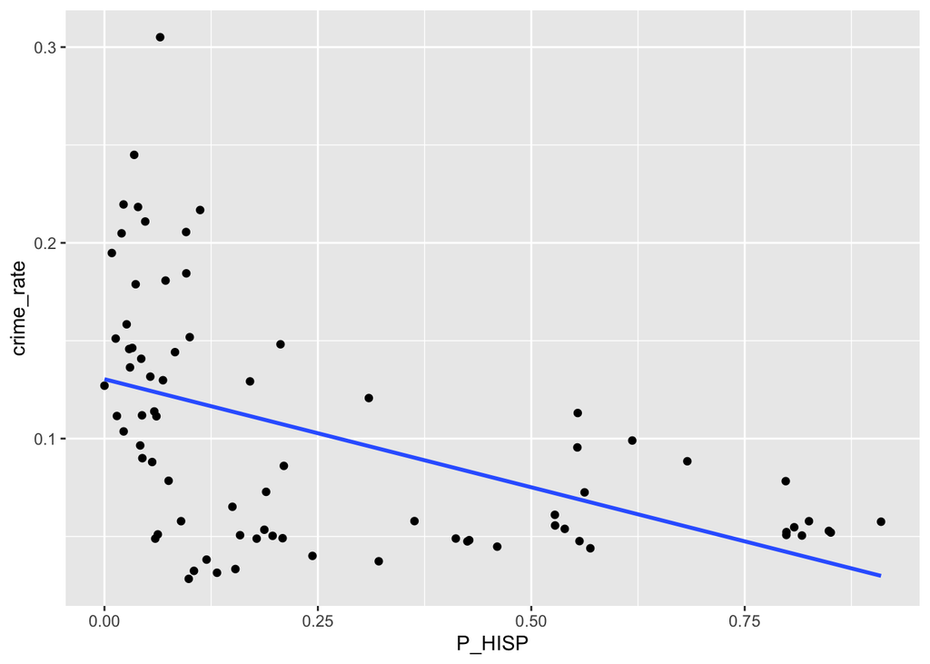

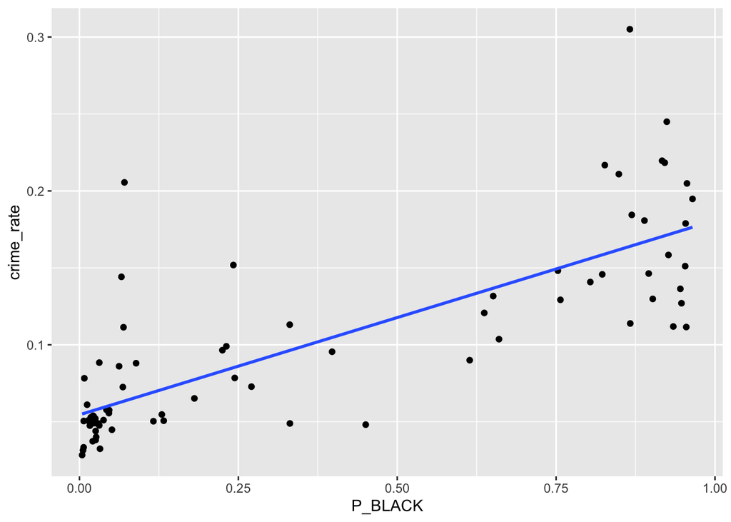

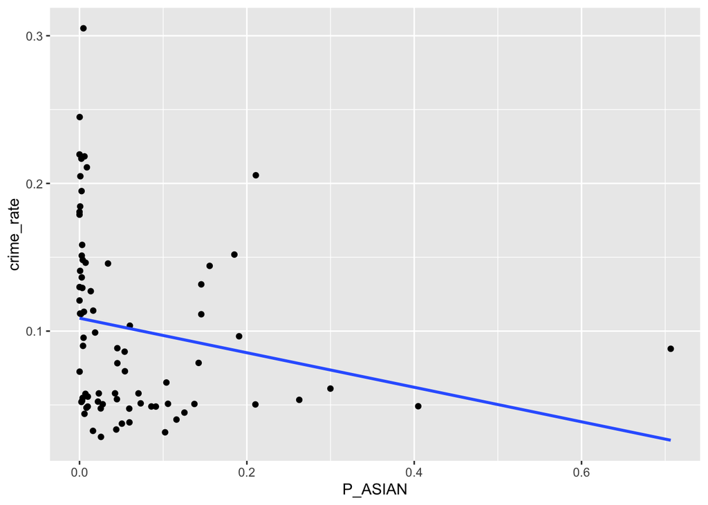

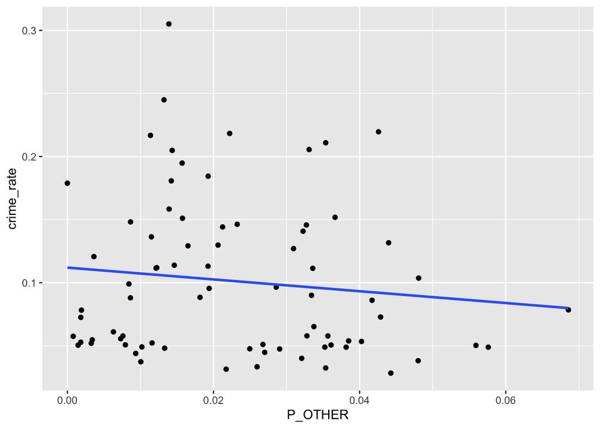

## Potential Shortcomings of the Analysis

While the analysis presented in this report provides valuable insights into the relationship between crime rates, unemployment, time periods, and race in Chicago community areas, there are several potential shortcomings to consider:

1. The analysis relies on reported crimes, which may not capture the full extent of criminal activity in the city. Unreported crimes or underreporting in certain areas could affect the accuracy of the findings.
2. The analysis focuses on a single year of data (2022) and does not consider long-term trends or changes over time. Analyzing data from multiple years could provide a more comprehensive understanding of the relationships between the variables.
3. The analysis does not account for other potential confounding factors that may influence crime rates, such as education levels, income inequality, access to social services, or community-specific characteristics. These factors could have significant impacts on crime rates but were not included in the current analysis.
4. The categorization of crimes into broad categories (e.g., violent crimes, property crimes) may oversimplify the complex nature of crime. Each category encompasses a range of different offenses with varying severity and underlying causes.
5. The analysis relies on statistical tests and correlations, which do not necessarily imply causation. While the findings suggest associations between variables, they do not establish causal relationships. Other factors not considered in the analysis may be driving the observed patterns.

## Future Directions for Additional Work

To address the limitations and expand upon the current analysis, several potential future directions can be explored:

### New Questions

- How have the relationships between crime rates, unemployment, time periods, and race changed over time in Chicago? Conducting a longitudinal analysis could reveal important trends and shifts in these relationships.
- What are the specific socioeconomic and community-level factors that contribute to crime rates in different areas of Chicago? Investigating variables such as education levels, income inequality, housing conditions, and access to resources could provide a more comprehensive understanding of the drivers of crime.
- How do the findings from Chicago compare to other major cities in the United States? Replicating the analysis in different urban contexts could shed light on the generalizability of the relationships observed in this study.

### Different Methods to Address the Same Questions

- Employ more advanced statistical techniques, such as multilevel modeling or spatial regression, to account for the hierarchical structure of the data and spatial dependencies between community areas.
- Conduct qualitative research, such as interviews or focus groups with community members, law enforcement officials, and policymakers, to gain a deeper understanding of the factors contributing to crime and the perceived effectiveness of interventions.
- Utilize machine learning algorithms to identify patterns and predict crime rates based on a wider range of variables, including demographic, socioeconomic, and environmental factors.

### New Data to Collect

- Gather data on additional socioeconomic indicators, such as education levels, income inequality, housing conditions, and access to social services, to incorporate into the analysis.
- Collect data on community-specific characteristics, such as social cohesion, collective efficacy, and neighborhood disorder, to explore their relationship with crime rates.
- Obtain data on crime prevention and intervention programs implemented in different community areas to assess their impact on crime rates over time.
- Collaborate with law enforcement agencies to access more detailed crime data, including information on specific offenses, victim characteristics, and offender profiles, to conduct more granular analyses.

# References https://catalog.data.gov/dataset/crimes-2001-to-present https://datahub.cmap.illinois.gov/datasets/CMAPGIS::community-data-snapshots-raw-data-2014-2022/explore?layer=21